# Practical Machine Learning: Course Project

Franz Eder

25 February 2016

```r
# set seed for reproducability on global level
set.seed(1401014)
```

## The Assignment

In course of the *Coursera* MOOC **Pratical Machine Learning**, it was our task in the final Course Project to use the *Weight Lifting Exercise Dataset* by Velloso et al. (2013) for building a model and predicting the manner in which six participants did perform barbell lifts (the dependent variable – `classe`) in 20 different test cases. We are allowed to use any of the remaining variables in the dataset.

The report should especially explain the following points:

1. How was the model build?
2. How was cross validation used?
3. What is the expected out of sample error?
4. Why were these choices made?

## Getting and Cleaning the Data

First, I downloaded the datasets and saved them to the data.frames `training` and `testing`.

```r
require(RCurl)
fileUrl1 <- "https://d396qusza40orc.cloudfront.net/predmachlearn/pml-training.csv"
download.file(url = fileUrl1, destfile = "training.csv", method = "curl")
fileUrl2 <- "https://d396qusza40orc.cloudfront.net/predmachlearn/pml-testing.csv"
download.file(url = fileUrl2, destfile = "testing.csv", method = "curl")

# loading data
training <- read.csv("training.csv", header = TRUE)
testing <- read.csv("testing.csv", header = TRUE)

dim(training)
```

```
## [1] 19622   160
```

```r
str(training[1:25])
```

```
## 'data.frame':    19622 obs. of  25 variables:
##  $ X                   : int  1 2 3 4 5 6 7 8 9 10 ...
##  $ user_name           : Factor w/ 6 levels "adelmo","carlitos",..: 2 2 2 2 2 2 2 2 2 2 ...
##  $ raw_timestamp_part_1: int  1323084231 1323084231 1323084231 1323084232 1323084232 1323084232 1323084232 1323084232 1323084232 1323084232 ...
##  $ raw_timestamp_part_2: int  788290 808298 820366 120339 196328 304277 368296 440390 484323 484434 ...
##  $ cvtd_timestamp      : Factor w/ 20 levels "02/12/2011 13:32",..: 9 9 9 9 9 9 9 9 9 9 ...
##  $ new_window          : Factor w/ 2 levels "no","yes": 1 1 1 1 1 1 1 1 1 1 ...
##  $ num_window          : int  11 11 11 12 12 12 12 12 12 12 ...
##  $ roll_belt           : num  1.41 1.41 1.42 1.48 1.48 1.45 1.42 1.42 1.43 1.45 ...
##  $ pitch_belt          : num  8.07 8.07 8.07 8.05 8.07 8.06 8.09 8.13 8.16 8.17 ...
##  $ yaw_belt            : num  -94.4 -94.4 -94.4 -94.4 -94.4 -94.4 -94.4 -94.4 -94.4 -94.4 ...
##  $ total_accel_belt    : int  3 3 3 3 3 3 3 3 3 3 ...
##  $ kurtosis_roll_belt  : Factor w/ 397 levels "","-0.016850",..: 1 1 1 1 1 1 1 1 1 1 ...
##  $ kurtosis_picth_belt : Factor w/ 317 levels "","-0.021887",..: 1 1 1 1 1 1 1 1 1 1 ...
##  $ kurtosis_yaw_belt   : Factor w/ 2 levels "","#DIV/0!": 1 1 1 1 1 1 1 1 1 1 ...
##  $ skewness_roll_belt  : Factor w/ 395 levels "","-0.003095",..: 1 1 1 1 1 1 1 1 1 1 ...
##  $ skewness_roll_belt.1: Factor w/ 338 levels "","-0.005928",..: 1 1 1 1 1 1 1 1 1 1 ...
##  $ skewness_yaw_belt   : Factor w/ 2 levels "","#DIV/0!": 1 1 1 1 1 1 1 1 1 1 ...
##  $ max_roll_belt       : num  NA NA NA NA NA NA NA NA NA NA ...
##  $ max_picth_belt      : int  NA NA NA NA NA NA NA NA NA NA ...
##  $ max_yaw_belt        : Factor w/ 68 levels "","-0.1","-0.2",..: 1 1 1 1 1 1 1 1 1 1 ...
##  $ min_roll_belt       : num  NA NA NA NA NA NA NA NA NA NA ...
##  $ min_pitch_belt      : int  NA NA NA NA NA NA NA NA NA NA ...
##  $ min_yaw_belt        : Factor w/ 68 levels "","-0.1","-0.2",..: 1 1 1 1 1 1 1 1 1 1 ...
##  $ amplitude_roll_belt : num  NA NA NA NA NA NA NA NA NA NA ...
##  $ amplitude_pitch_belt: int  NA NA NA NA NA NA NA NA NA NA ...
```

A first look at the `training` dataset shows that there are 19622 observations and 160 variables. However, there are also a lot of `NA` and `Factor` variables. Consequently, I removed all varibales with more than 50 % `NA` and which were not numeric. Finally, I also removed the first four varibales, because these variables were only time stamps or row numbers.

```r
classeTrain <- training$classe
# deleting columns where share of NAs is 50 %
training <- training[, colSums(is.na(training)) < nrow(training) * 0.5]
# delete all columns which are not numeric
training <- training[sapply(training, is.numeric)]
# remove first 4 columns
training <- training[, -c(1:4)]
training$classe <- classeTrain

classeTest <- testing$classe
# deleting columns where share of NAs is 50 %
testing <- testing[, colSums(is.na(testing)) < nrow(testing) * 0.5]
# delete all columns which are not numeric
testing <- testing[sapply(testing, is.numeric)]
# remove first 4 columns
testing <- testing[, -c(1:4)]
testing$classe <- classeTest
```

## Basic Exploratory Data Analysis

As the correlation plot shows, there are some variables which highly corrolate with each other. Hence, I had to decide whether to remove them or to use methods that can handle this problem.

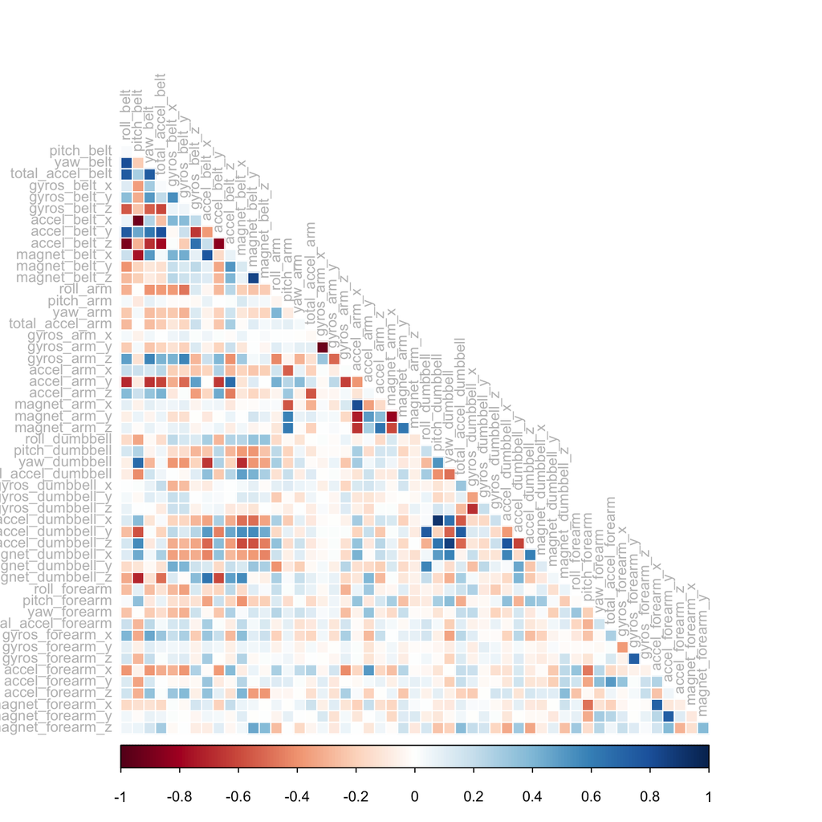

```r
require(corrplot)
corrPlot <- cor(training[, -53], method = "spearman")
corrplot(corrPlot, method = "color", type = "lower", tl.cex = .8, diag = FALSE,
         tl.col = "grey", insig = "blank")
```

## Train and Evaluate Models

To train and evaluate the models, I divided the `training` dataset into two subsets: a `subTraining` and a `subTesting` dataset, so that the models need not to be tested on the final `testing` dataset. Furthermore, I used the `trainControl` function for crossvalidation, breaking the dataset in five sets.

```r
require(caret)

# Create a building data set
inTrain <- createDataPartition(training$classe, p = 0.6, list = FALSE)
subTraining <- training[inTrain,]
subTesting <- training[-inTrain,]

# use cross validation
control <- trainControl(method = "cv", 5)
```

I decided to use test three models:

1. `rpart`: Predicting with trees, because these models are easy to implement, easy to interpret and have a better performance in nonlinear settings (see [slides](https://github.com/jtleek/modules/blob/master/08_PredictionAndMachineLearning/019predictingWithTrees/index.md)).
2. `gbm`: Predicting with boosting, because these models take lots of (possibly) weak predictors, weight them and add them up and hence get a stronger predictor (see [slides](https://github.com/jtleek/modules/blob/master/08_PredictionAndMachineLearning/022boosting/index.md)).
3. `rf`: Predicting with random forsts, because these models have a high accuracy. However they are slow and tend to be overfitting (see [slides](https://github.com/jtleek/modules/blob/master/08_PredictionAndMachineLearning/021randomForests/index.md)).

```r
# use parallel processing
require(doMC)
registerDoMC(cores = 3)

modelRPART <- train(classe ~ ., method = "rpart", trControl = control, data = subTraining)
modelGBM <- train(classe ~ ., method = "gbm", trControl = control, data = subTraining)
modelRF <- train(classe ~ ., method = "rf", trControl = control, data = subTraining)
```

I then tested all models on the `subTesting` dataset and created a confusion matrix to show, how good the predictions are.

```r
testingRPART <- predict(modelRPART, subTesting)
confusionMatrix(subTesting$classe, testingRPART)
```

```
## Confusion Matrix and Statistics
##
##           Reference
## Prediction    A    B    C    D    E
##          A 1994   37  169    0   32
##          B  648  514  356    0    0
##          C  657   45  666    0    0
##          D  572  223  491    0    0
##          E  208  181  402    0  651
##
## Overall Statistics
##
##                Accuracy : 0.4875
##                  95% CI : (0.4764, 0.4986)
##     No Information Rate : 0.5199
##     P-Value [Acc > NIR] : 1
##
##                   Kappa : 0.3302
##  Mcnemar's Test P-Value : NA
##
## Statistics by Class:
##
##                      Class: A Class: B Class: C Class: D Class: E
## Sensitivity            0.4888  0.51400  0.31958       NA  0.95315
## Specificity            0.9368  0.85335  0.87817   0.8361  0.88957
## Pos Pred Value         0.8934  0.33860  0.48684       NA  0.45146
## Neg Pred Value         0.6286  0.92320  0.78111       NA  0.99500
## Prevalence             0.5199  0.12745  0.26561   0.0000  0.08705
## Detection Rate         0.2541  0.06551  0.08488   0.0000  0.08297
## Detection Prevalence   0.2845  0.19347  0.17436   0.1639  0.18379
## Balanced Accuracy      0.7128  0.68367  0.59887       NA  0.92136
```

```r
testingGBM <- predict(modelGBM, subTesting)
confusionMatrix(subTesting$classe, testingGBM)
```

```
## Confusion Matrix and Statistics
##
##           Reference
## Prediction    A    B    C    D    E
##          A 2185   36    6    4    1
##          B   58 1414   43    1    2
##          C    0   41 1308   18    1
##          D    2    5   57 1216    6
##          E    3   18   15   26 1380
##
## Overall Statistics
##
##                Accuracy : 0.9563
##                  95% CI : (0.9515, 0.9607)
##     No Information Rate : 0.2865
##     P-Value [Acc > NIR] : < 2.2e-16
##
##                   Kappa : 0.9447
##  Mcnemar's Test P-Value : 9.914e-12
##
## Statistics by Class:
##
##                      Class: A Class: B Class: C Class: D Class: E
## Sensitivity            0.9720   0.9339   0.9153   0.9613   0.9928
## Specificity            0.9916   0.9836   0.9906   0.9894   0.9904
## Pos Pred Value         0.9789   0.9315   0.9561   0.9456   0.9570
## Neg Pred Value         0.9888   0.9842   0.9813   0.9925   0.9984
## Prevalence             0.2865   0.1930   0.1821   0.1612   0.1772
## Detection Rate         0.2785   0.1802   0.1667   0.1550   0.1759
## Detection Prevalence   0.2845   0.1935   0.1744   0.1639   0.1838
## Balanced Accuracy      0.9818   0.9588   0.9530   0.9753   0.9916
```

```r
testingRF <- predict(modelRF, subTesting)
confusionMatrix(subTesting$classe, testingRF)
```

```
## Confusion Matrix and Statistics
##
##           Reference
## Prediction    A    B    C    D    E
##          A 2229    3    0    0    0
##          B   17 1499    2    0    0
##          C    0    7 1353    8    0
##          D    0    1   26 1259    0
##          E    0    0    2    9 1431
##
## Overall Statistics
##
##                Accuracy : 0.9904
##                  95% CI : (0.988, 0.9925)
##     No Information Rate : 0.2863
##     P-Value [Acc > NIR] : < 2.2e-16
##
##                   Kappa : 0.9879
##  Mcnemar's Test P-Value : NA
##
## Statistics by Class:
##
##                      Class: A Class: B Class: C Class: D Class: E
## Sensitivity            0.9924   0.9927   0.9783   0.9867   1.0000
## Specificity            0.9995   0.9970   0.9977   0.9959   0.9983
## Pos Pred Value         0.9987   0.9875   0.9890   0.9790   0.9924
## Neg Pred Value         0.9970   0.9983   0.9954   0.9974   1.0000
## Prevalence             0.2863   0.1925   0.1763   0.1626   0.1824
## Detection Rate         0.2841   0.1911   0.1724   0.1605   0.1824
## Detection Prevalence   0.2845   0.1935   0.1744   0.1639   0.1838
## Balanced Accuracy      0.9959   0.9949   0.9880   0.9913   0.9991
```

As the confusion matrices show, the **prediction with trees** is the worst metthod. It has an accuracy of 48.75 per cent, which means the result are as good/bad as by predicting by chance.

Predicting with **boosting** is much better. This method has an accuracy of 95.63 per cent and hence is almost perfect. Nevertheless, predicting with **random forests** is even better. It has an **accuracy of 99.04 per cent** and an **expected out of sample error of 0.96 per cent**.

```r
print(modelRF)
```

```
## Random Forest
##
## 11776 samples
##    52 predictor
##     5 classes: 'A', 'B', 'C', 'D', 'E'
##
## No pre-processing
## Resampling: Cross-Validated (5 fold)
## Summary of sample sizes: 9422, 9420, 9422, 9420, 9420
## Resampling results across tuning parameters:
##
##   mtry  Accuracy   Kappa      Accuracy SD  Kappa SD
##    2    0.9882803  0.9851734  0.003949196  0.004998102
##   27    0.9887903  0.9858198  0.001463159  0.001850389
##   52    0.9808946  0.9758303  0.003837491  0.004855569
##
## Accuracy was used to select the optimal model using  the largest value.
## The final value used for the model was mtry = 27.
```

This model uses 27 variables for splitting at each tree node. The ten most important variables in this model are as follows:

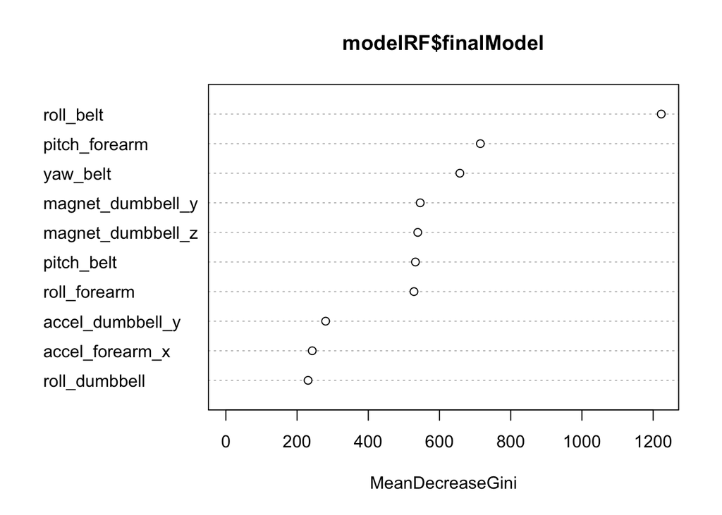

```r
varImpPlot(modelRF$finalModel, n.var = 10)
```

Consequently, I chose the Random Forest model, not just because it has the highest accuracy and hence the lowest expected out of sample error. I also chose this method because highly correlated variables do not cause multi-collinearity issues in Random Forst models.

## Applying the Best Model to Testing Dataset

Finnaly, I applied the Random Forest model to the `testing` dataset and got the following results, which I submitted to *Course Project Prediction Quiz*:

```r
predict(modelRF, testing)
```

```
##  [1] B A B A A E D B A A B C B A E E A B B B
## Levels: A B C D E
```

## Literature

Velloso, E.; Bulling, A.; Gellersen, H.; Ugulino, W.; Fuks, H. Qualitative Activity Recognition of Weight Lifting Exercises. Proceedings of 4th International Conference in Cooperation with SIGCHI (Augmented Human ’13) . Stuttgart, Germany: ACM SIGCHI, 2013.